### Data

OECD Regional Well-Being data (2019) is used here. The data shows how regions perform when it comes to education, environment, safety and other topics important to your well-being. This interactive site allows you to measure well-being in your region and compare it with 402 other OECD regions based on eleven topics central to the quality of our lives.

Source: https://www.oecdregionalwellbeing.org/

- Labour force with at least secondary education (in %): `Labour`
- Employment rate (in %): `Employment`
- Unemployment rate (in %): `Unemployment`
- Household disposable income per capita (in constant USD PPP): `Household`
- Homicide rate (per 100000 people): `Homicide`
- Mortality rate (per 100000 people): `Mortality`
- Life expectancy (in number of years): `Life`
- Air pollution (level of PM2.5, in $\mu g/ m^3$): `Air`
- Voter turnout (in %): `Voter`
- Broadband access (in % of households): `Broadband`
- Number of rooms per person (rooms per person): `Number`
- Perceived social network support (in %): `Perceived`
- Self assessment of life satisfaction (index 0 to 10): `Self`

### Observed Difference

For the countries `Poland` and `Germany` and the variable `Labour` (Labour force with at least secondary education (in %)) it turns out that

- $\bar{x}_{\text{Germany}} = 87.84$
- $\bar{x}_{\text{Poland}} = 93.97$

So that

$$\bar{x}_{\text{Poland}} - \bar{x}_{\text{Germany}} = 93.97 - 87.84 = 6.12$$

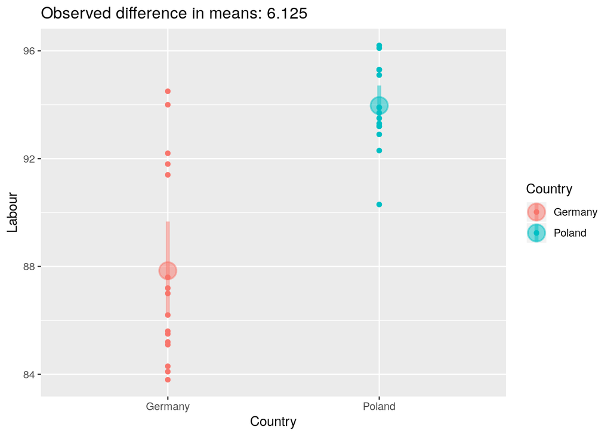

### Permuted differences plot

But what if the distribution of the data generating process would be the same for both countries, formally: $F(x)_{\text{Germany}}=F(x)_{\text{Poland}}$? If this hypothetical model is true than the oberservations can be shuffled, i.e. permuted. If the value for `Labour` is identical distributed for both countries (`Germany` and `Poland`) than it does not matter if an observation comes from Poland or Germany. Identical distribution also leads to:

$$H_0: \mu_{\text{Germany}}=\mu_{\text{Poland}} \Leftrightarrow \mu_{\text{Poland}}- \mu_{\text{Germany}}=0$$

Considering randomness, statistical hypothesis test ask: if the null hypothesis (here: no difference) would be true, what is the probability of an at least as extreme difference as the one in the observed sample?

We can simulate data according to the model $F(x)_{\text{Germany}}=F(x)_{\text{Poland}}$ by random permutation of the country:

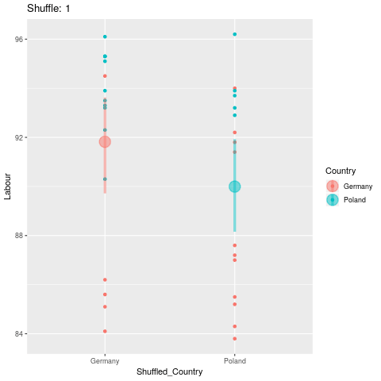

The next figure shows the differences after permutation for each shuffle:

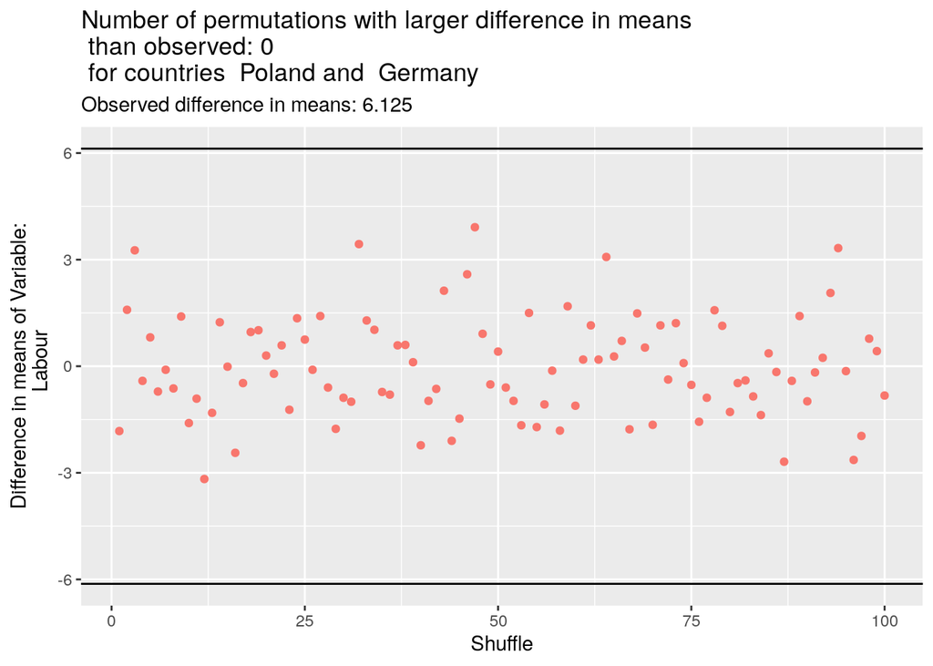

The permutated differences $\bar{x}^*_{\text{Poland}} - \bar{x}^*_{\text{Germany}}$ are in the range of $\pm 4$ and never reach the observed difference of $6.12$.

### Permutation Distribution

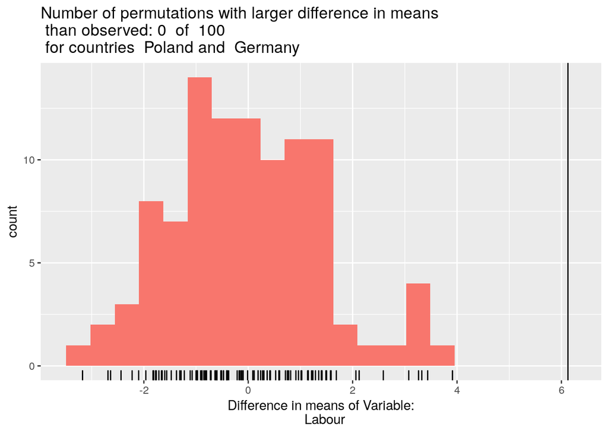

The histogram of the permutation distributions shows again that in this case it is very unlikely that, if $H_0$ would be true, we observe a difference of $6.12$ in a sample as we did. This leads to a rejection of $H_0$ as the data we have is not compatible to the model (no difference in distribution) that we hypothetically assumed.